# Card (1995) — Design Diagnostics & Weight Stability

Why is the Effective Sample Size so Low? Propensity Scores, Overlap, and Weak Instrument

Alexander Unger

09 June 2026

```r
library(haven)
library(dplyr)
library(tidyr)
library(ggplot2)
library(knitr)
library(kableExtra)
library(AER)
library(sandwich)
library(lmtest)
library(scales)

# Shared kappa toolkit (logit_mle, get_cbps_p, kappa_outcome_weights,
# kappa_weights, weight_diag, ...). Nothing estimation-related is defined here.
source("functions_all.R")

# Consistent palette
col_z1   <- "#2c7bb6"   # Z = 1 (near college)
col_z0   <- "#d7191c"   # Z = 0 (far from college)
col_grey <- "#4d4d4d"
col_card <- "#2166ac"
col_kit  <- "#984ea3"
```

```r
data_path <- "/Users/alexung/Desktop/master_thesis/code/"
card      <- read_dta(file.path(data_path, "card.dta"))
card      <- card[!is.na(card$wage) & !is.na(card$educ), ]

# Treatments, instrument, covariates
card$somecol <- as.integer(card$educ > 12)    # D1: some college
card$educ16  <- as.integer(card$educ >= 16)   # D2: college completion
card$Z       <- as.integer(card$nearc4)       # Z: grew up near 4-yr college
if (!"expersq" %in% names(card)) card$expersq <- card$exper^2

# Propensity scores p(X) = Pr(Z = 1 | X) under both specs
X_card <- model.matrix(~ exper + expersq + black + south + smsa + smsa66 +
                          reg661+reg662+reg663+reg664+reg665+reg666+reg667+reg668, card)
X_kit  <- model.matrix(~ black + south + smsa + smsa66 + south66, card)

card$p_card <- logit_mle(card$Z, X_card)
card$p_kit  <- logit_mle(card$Z, X_kit)

cat(sprintf("N = %d | Pr(Z=1) = %.3f | somecol = %.3f | educ16 = %.3f\n",
            nrow(card), mean(card$Z), mean(card$somecol), mean(card$educ16)))
```

```
## N = 3010 | Pr(Z=1) = 0.682 | somecol = 0.505 | educ16 = 0.271
```

# 1. The Puzzle

**The finding to explain.** In the Card application the effective sample size (ESS = $1/\sum_i \omega_i^2$) of the kappa weights collapses to single digits — for the Kitagawa specification it falls near 1 — even though $N = 3{,}010$. This notebook diagnoses *why*, working through three candidate explanations: (1) a **weak first stage**, (2) **propensity-score concentration / non-overlap**, and (3) **sign-reversing observations** (high $\hat p(X)$ yet $Z=0$ and treated, or the reverse) that destabilize the kappa weights.

```r
# Quick ESS preview across both specs and both treatments
ess_one <- function(D, p) {
  w <- kappa_outcome_weights(card$Z, D, p)$w_u
  1 / sum(w^2)
}
ess_tab <- data.frame(
  Specification = c("Card", "Kitagawa"),
  `somecol (ESS)` = c(ess_one(card$somecol, card$p_card),
                      ess_one(card$somecol, card$p_kit)),
  `educ16 (ESS)`  = c(ess_one(card$educ16,  card$p_card),
                      ess_one(card$educ16,  card$p_kit)),
  check.names = FALSE
)
ess_tab[,2:3] <- round(ess_tab[,2:3], 1)

ess_tab %>%
  kbl(caption = "Effective sample size (τ_ml_u weights) — the puzzle in one table",
      align = c("l","r","r")) %>%
  kable_styling(bootstrap_options = c("striped","hover","condensed"),
                full_width = FALSE, font_size = 14) %>%
  column_spec(2:3, bold = TRUE, color = "#d7191c") %>%
  footnote(general = sprintf("Out of N = %d observations. ESS this low means a handful of observations carry essentially all the weight.", nrow(card)))
```

Effective sample size (τ_ml_u weights) — the puzzle in one table

| Specification | somecol (ESS) | educ16 (ESS) |
| --- | --- | --- |
| Card | 3.8 | 1.1 |
| Kitagawa | 2.9 | 0.9 |

# 2. First Stage: Is the Instrument Weak?

**Why this matters.** The kappa weights divide by the conditional first stage. A weak instrument means $\Pr(D=1\mid Z=1,X) - \Pr(D=1\mid Z=0,X)$ is small for many cells; dividing by a near-zero first stage inflates weights and destroys ESS. Card’s instrument (college proximity) is known to be weaker than the Vietnam draft lottery.

```r
fs_F <- function(formula, data) {
  fit <- lm(formula, data = data)
  ct  <- coeftest(fit, vcov = vcovHC(fit, type = "HC1"))
  c(coef = unname(ct["Z","Estimate"]),
    se   = unname(ct["Z","Std. Error"]),
    F    = unname((ct["Z","Estimate"]/ct["Z","Std. Error"])^2))
}

# First stage for both treatments and both specs
fs_rows <- rbind(
  data.frame(Treatment="somecol", Spec="Card",
             t(fs_F(somecol ~ Z + exper+expersq+black+south+smsa+smsa66+
                      reg661+reg662+reg663+reg664+reg665+reg666+reg667+reg668, card))),
  data.frame(Treatment="somecol", Spec="Kitagawa",
             t(fs_F(somecol ~ Z + black+south+smsa+smsa66+south66, card))),
  data.frame(Treatment="educ16", Spec="Card",
             t(fs_F(educ16 ~ Z + exper+expersq+black+south+smsa+smsa66+
                      reg661+reg662+reg663+reg664+reg665+reg666+reg667+reg668, card))),
  data.frame(Treatment="educ16", Spec="Kitagawa",
             t(fs_F(educ16 ~ Z + black+south+smsa+smsa66+south66, card)))
)
fs_rows$coef <- round(fs_rows$coef, 4)
fs_rows$se   <- round(fs_rows$se, 4)
fs_rows$F    <- round(fs_rows$F, 1)
fs_rows$`Stock-Yogo (>10)?` <- ifelse(fs_rows$F >= 10, "✓ strong", "✗ WEAK")

fs_rows %>%
  kbl(caption = "First-stage strength: effect of college proximity (Z) on each treatment",
      col.names = c("Treatment","Spec","First stage δ̂","SE","F-stat","Stock-Yogo (>10)?"),
      align = c("l","l","r","r","r","c")) %>%
  kable_styling(bootstrap_options = c("striped","hover","condensed"),
                full_width = TRUE, font_size = 13) %>%
  row_spec(which(fs_rows$F < 10), background = "#fdeaea", bold = TRUE) %>%
  footnote(general = "HC1-robust first-stage F on the instrument. Compare to Vietnam, where F was far above 10. A weak first stage here is the first driver of weight instability.")
```

First-stage strength: effect of college proximity (Z) on each treatment

| Treatment | Spec | First stage δ̂ | SE | F-stat | Stock-Yogo (>10)? |
| --- | --- | --- | --- | --- | --- |
| somecol | Card | 0.0636 | 0.0180 | 12.5 | ✓ strong |
| somecol | Kitagawa | 0.0653 | 0.0218 | 9.0 | ✗ WEAK |
| educ16 | Card | 0.0302 | 0.0162 | 3.5 | ✗ WEAK |
| educ16 | Kitagawa | 0.0379 | 0.0191 | 3.9 | ✗ WEAK |

Note:  
HC1-robust first-stage F on the instrument. Compare to Vietnam, where F was far above 10. A weak first stage here is the first driver of weight instability.

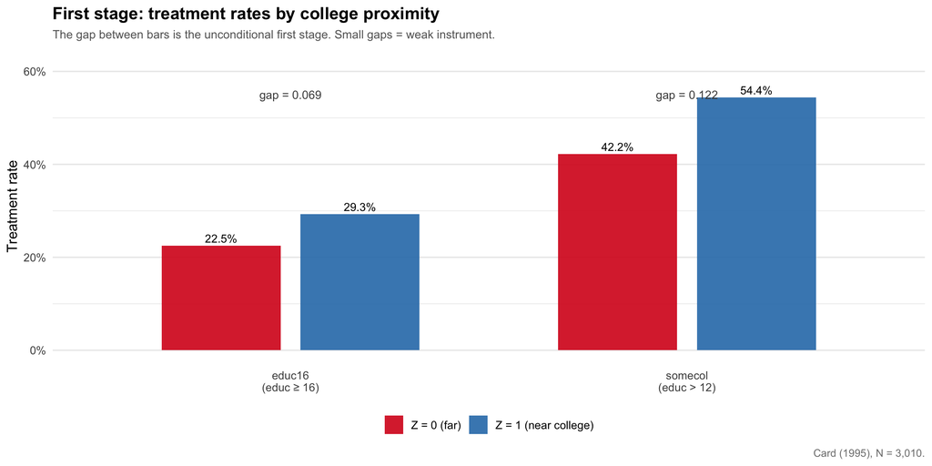

```r
# First-stage gap: D-rate by Z, for somecol
fs_gap <- card %>%
  summarise(
    `Z = 1 (near college)` = mean(somecol[Z == 1]),
    `Z = 0 (far)`          = mean(somecol[Z == 0])
  )
gap_some <- fs_gap$`Z = 1 (near college)` - fs_gap$`Z = 0 (far)`

fs_gap_e <- card %>%
  summarise(
    `Z = 1 (near college)` = mean(educ16[Z == 1]),
    `Z = 0 (far)`          = mean(educ16[Z == 0])
  )
gap_educ <- fs_gap_e$`Z = 1 (near college)` - fs_gap_e$`Z = 0 (far)`

fs_plot_df <- data.frame(
  Treatment = rep(c("somecol\n(educ > 12)", "educ16\n(educ ≥ 16)"), each = 2),
  Z = rep(c("Z = 1 (near college)", "Z = 0 (far)"), 2),
  rate = c(fs_gap$`Z = 1 (near college)`, fs_gap$`Z = 0 (far)`,
           fs_gap_e$`Z = 1 (near college)`, fs_gap_e$`Z = 0 (far)`)
)

ggplot(fs_plot_df, aes(x = Treatment, y = rate, fill = Z)) +
  geom_col(position = position_dodge(0.7), width = 0.6, alpha = 0.9) +
  geom_text(aes(label = sprintf("%.1f%%", 100*rate)),
            position = position_dodge(0.7), vjust = -0.4, size = 3.4) +
  annotate("text", x = 1, y = 0.55,
           label = sprintf("gap = %.3f", gap_educ), size = 3.5, colour = col_grey) +
  annotate("text", x = 2, y = 0.55,
           label = sprintf("gap = %.3f", gap_some), size = 3.5, colour = col_grey) +
  scale_fill_manual(values = c("Z = 1 (near college)" = col_z1, "Z = 0 (far)" = col_z0)) +
  scale_y_continuous(labels = percent_format(accuracy = 1), limits = c(0, 0.62)) +
  labs(title = "First stage: treatment rates by college proximity",
       subtitle = "The gap between bars is the unconditional first stage. Small gaps = weak instrument.",
       x = NULL, y = "Treatment rate", fill = NULL,
       caption = "Card (1995), N = 3,010.") +
  theme_minimal(base_size = 12) +
  theme(legend.position = "bottom", panel.grid.major.x = element_blank(),
        plot.title = element_text(face = "bold"),
        plot.subtitle = element_text(colour = "grey40", size = 10),
        plot.caption = element_text(colour = "grey50", size = 9))
```

# 3. Propensity Score: Concentration & Overlap

**Why this matters.** The kappa weights contain $1/p(X)$ and $1/(1-p(X))$ terms. Observations with $\hat p(X)$ near 0 or 1 get enormous weights. Unlike Vietnam (where $\hat p$ was tightly clustered around 0.46 by design), the richer Card and Kitagawa covariate sets can push $\hat p(X)$ toward the boundaries — directly inflating weights.

## Summary Statistics

```r
ps_summary <- function(p, name) {
  data.frame(Specification = name,
             Min = min(p), P05 = quantile(p,0.05), P25 = quantile(p,0.25),
             Mean = mean(p), P75 = quantile(p,0.75), P95 = quantile(p,0.95),
             Max = max(p), SD = sd(p),
             `near 0/1` = mean(p < 0.05 | p > 0.95),
             check.names = FALSE)
}
ps_tab <- bind_rows(ps_summary(card$p_card, "Card (14 covariates)"),
                    ps_summary(card$p_kit,  "Kitagawa (5 covariates)"))
ps_tab[,2:10] <- lapply(ps_tab[,2:10], function(x) round(x, 4))

ps_tab %>%
  kbl(caption = "Propensity score p̂(X) = Pr(Z=1|X): summary by specification",
      align = c("l", rep("r", 9))) %>%
  kable_styling(bootstrap_options = c("striped","hover","condensed"),
                full_width = TRUE, font_size = 12.5) %>%
  column_spec(9, bold = TRUE) %>%
  column_spec(10, bold = TRUE, color = "#d7191c") %>%
  footnote(general = "Compare SD and the 'near 0/1' share against Vietnam (SD ≈ 0.10, essentially nothing near the boundaries). Higher dispersion here is the second driver of low ESS.")
```

Propensity score p̂(X) = Pr(Z=1|X): summary by specification

|  | Specification | Min | P05 | P25 | Mean | P75 | P95 | Max | SD | near 0/1 |
| --- | --- | --- | --- | --- | --- | --- | --- | --- | --- | --- |
| 5%…1 | Card (14 covariates) | 0.1724 | 0.2459 | 0.4376 | 0.6821 | 0.8726 | 0.9341 | 0.9517 | 0.2356 | 0.0056 |
| 5%…2 | Kitagawa (5 covariates) | 0.2532 | 0.2532 | 0.4554 | 0.6821 | 0.8783 | 0.8783 | 0.9067 | 0.2280 | 0.0000 |

Note:  
Compare SD and the ‘near 0/1’ share against Vietnam (SD ≈ 0.10, essentially nothing near the boundaries). Higher dispersion here is the second driver of low ESS.

## Distribution by Instrument Status

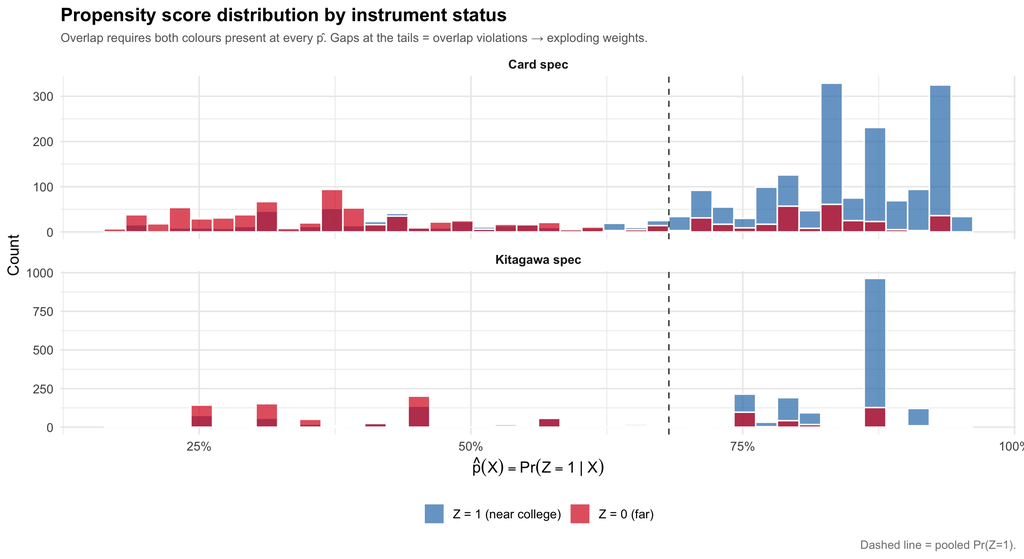

```r
ps_long <- card %>%
  select(p_card, p_kit, Z) %>%
  pivot_longer(c(p_card, p_kit), names_to = "spec", values_to = "p_hat") %>%
  mutate(Specification = factor(spec,
                                levels = c("p_card", "p_kit"),
                                labels = c("Card spec", "Kitagawa spec")),
         Zlab = factor(ifelse(Z == 1, "Z = 1 (near college)", "Z = 0 (far)"),
                       levels = c("Z = 1 (near college)", "Z = 0 (far)")))

ggplot(ps_long, aes(x = p_hat, fill = Zlab)) +
  geom_histogram(bins = 40, alpha = 0.7, colour = "white", position = "identity") +
  geom_vline(xintercept = mean(card$Z), linetype = "dashed", colour = col_grey) +
  facet_wrap(~ Specification, ncol = 1, scales = "free_y") +
  scale_fill_manual(values = c("Z = 1 (near college)" = col_z1, "Z = 0 (far)" = col_z0)) +
  scale_x_continuous(labels = percent_format(accuracy = 1)) +
  labs(title = "Propensity score distribution by instrument status",
       subtitle = "Overlap requires both colours present at every p̂. Gaps at the tails = overlap violations → exploding weights.",
       x = expression(hat(p)(X) == Pr(Z == 1 ~ "|" ~ X)), y = "Count", fill = NULL,
       caption = "Dashed line = pooled Pr(Z=1).") +
  theme_minimal(base_size = 12) +
  theme(legend.position = "bottom", strip.text = element_text(face = "bold"),
        plot.title = element_text(face = "bold"),
        plot.subtitle = element_text(colour = "grey40", size = 9.5),
        plot.caption = element_text(colour = "grey50", size = 9))
```

**What to look for.** Where the red (Z=0) bars vanish at high $\hat p$, or blue (Z=1) bars vanish at low $\hat p$, the inverse-probability terms $Z/p$ and $(1-Z)/(1-p)$ have no counterpart to balance against — those observations receive extreme weights. The Kitagawa panel, with only 5 binary covariates, produces discrete $\hat p$ clumps that are especially prone to this.